# finalProject

**World of Warcraft Mythic Dungeon Representation Analysis**

Joseph C. Bernstein

Every patch of World of Warcraft releases a new raid tier and season. Each expansion contains a range of dungeons that five people will enter and attempt to complete. There have been varying difficulties over the years, but more recently, it has been toned to normal, heroic, and mythic difficulties, with mythic containing a trial mode based on an affix and key system. The affixes rotate weekly, always alternating between extra dungeon boss health and damage, and extra non-boss enemy health and damage. To expand a bit more on the key system, after a dungeon is completed, a key to a random dungeon is dropped for all members. This key increases the difficulty of the next dungeon, scaling infinitely. Rewards are capped at +15, but the score reward is uncapped. Groups will try to push higher keys in an attempt to gain more score for the leaderboards.

Each dungeon group contains a tank, a healer, and 3 damage dealers. The focus of this document is to analyze damage dealer class performance and representation, and if possible, attempt to identify which types of classes have a history of success to determine which type of class to play going into the new WoW expansion: Dragonflight.

```python
# Imports for project
import requests
from bs4 import BeautifulSoup as bs
import pandas as pd
import numpy as np
import matplotlib.pyplot as plt
import seaborn as sns
from sklearn import linear_model

#Set figure size
sns.set(rc = {'figure.figsize':(18,8)})
#Set covenant colors for graphs
palletteUse = {'Venthyr': 'red', 'Kyrian': 'blue', 'Necrolord': 'green', 'Nightfae': 'purple'}
```

To start, let's look at the most recent season in the 9.2 patch of the expansion: Shadowlands. To do so, we have a number of options.

1. Raider.io is a website that pulls from the warcraft api to compile comprehensive leaderboards for raid and dungeon rankings.
2. Warcraftlogs is another site that takes in user generate combat logs and completes statistical analysis on individual and class performance, but Warcraftlogs is used primarily for raid encounters.
3. Access the warcraft API directly from https://develop.battle.net/documentation/world-of-warcraft/game-data-apis. For this third option, you will need a Blizzard Dev account, which is easy to make, and an OAuth Access token from the Dev account. After making an account from the provided website, enter the client ID and client secret string to enable access to the API. The API's provided contain access to individual player look ups, Mythic Plus dungeon leaderboards by realm, specific dungeon content, and a plethora of other specific information access.

From raider.io we can pull each classes' spec performers over the 9.2 mythic dungeon season patch. The Score associated with each player is calculated based on the highest level completion (with a bonus to competions within the time limit) across all dungeons in the expansion. Each dungeon carries a high score, and the total player score value is aggregated across all available dungeons. In short, a higher score means higher average difficulty dungeon competions. From this report, we can upload the information into a CSV that is available in the github repository supporting this webpage here:https://github.com/jewjojo/jBernsteinCs320Final.

For access to the original data, please visit https://raider.io/ and https://raider.io/api#/, or use the blizzard Mythic Keystone Dungeon API. The blizzard API will return the leaderboards for each dungeon, including each player and class information. The same information is available on raider.io's leaderboard page, or mythic-plus/runs API lookup. With the lookup, one can search the top players manually, but the raider.io page is a quicker and cleaner alternative.

The data stored within the following table contains the top 10 players for each dps specialization for each class.

```python
Dungeon92Ranks = pd.read_csv('WowDungeon9.2Rankings.csv')
Dungeon92Ranks
```

|  | Class | Spec | Rank | Covenant | Score |
| --- | --- | --- | --- | --- | --- |
| 0 | Death Knight | Frost DK | 1 | Nightfae | 3672.0 |
| 1 | Death Knight | Frost DK | 2 | Nightfae | 3590.3 |
| 2 | Death Knight | Frost DK | 3 | Kyrian | 3557.0 |
| 3 | Death Knight | Frost DK | 4 | Nightfae | 3554.3 |
| 4 | Death Knight | Frost DK | 5 | Nightfae | 3548.8 |
| ... | ... | ... | ... | ... | ... |
| 235 | Warrior | Fury | 6 | Nightfae | 3670.0 |
| 236 | Warrior | Fury | 7 | Kyrian | 3634.0 |
| 237 | Warrior | Fury | 8 | Kyrian | 3622.5 |
| 238 | Warrior | Fury | 9 | Kyrian | 3610.6 |
| 239 | Warrior | Fury | 10 | Necrolord | 3585.0 |

240 rows × 5 columns

For a surface level analysis, let's plot the average score by class.

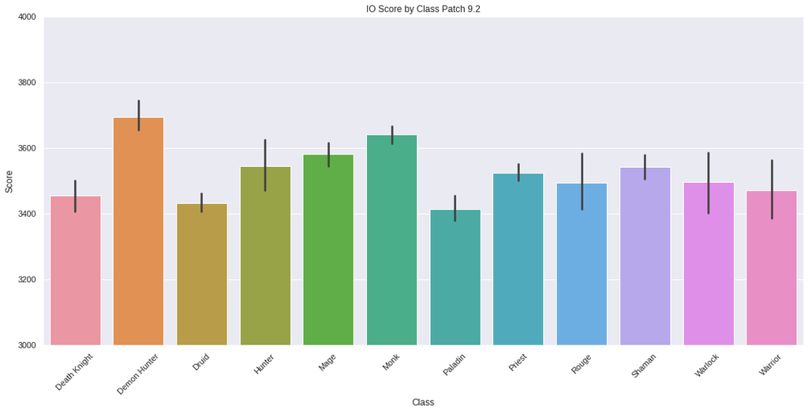

```python
sns.barplot(x='Class', y='Score', data=Dungeon92Ranks)
plt.xticks(rotation=45)
plt.style.use('seaborn-white')
plt.title('IO Score by Class Patch 9.2')
plt.xlabel('Class')
plt.ylabel('Score')
plt.ylim(3000, 4000)
plt.show()
```

From this plot, we can see a close race between all the classes. Paladins seem to be falling behind, along with Death Knights, and Demon Hunters seem to be pulling ahead, but is there any difference between specs?

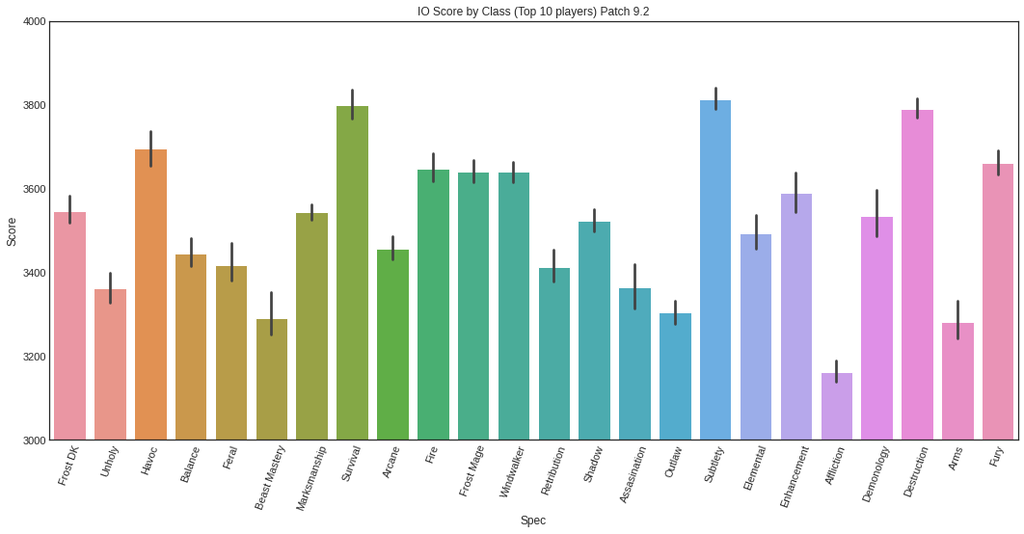

```python
sns.barplot(x='Spec', y='Score', data=Dungeon92Ranks)
plt.xticks(rotation=70)
plt.style.use('seaborn-white')
plt.title('IO Score by Class (Top 10 players) Patch 9.2')
plt.xlabel('Spec')
plt.ylabel('Score')
plt.ylim(3000, 4000)
plt.show()
```

With this further delineation, we can see greater discrepencies between specialization performance over the last patch. Affliction warlocks have fallen off a cliff in terms of high end performance, while destruction warlock is excelling to be a top contendor. Without digging into specific spec analysis, one might assume warlocks to be a middle of the road class. The same can be said of Beast Mastery and survival hunters, who are facing a similar delima. One spec is soaring while the other tanks in IO score. Demon hunters as well seemed to be taking the lead, but once the classes were split by spec, we can see Sub rouges, Survival hunters, and Destruction warlocks to be in the lead in IO.

Before moving into the history of each class over the expansion, we have yet to address another major component within the data set. One of the key selling features of the Shadowlands expansion for World of Warcraft was the Covenant system. Each player selects a faction (covenant) to join, and along with cosmetic rewards, they gain two additional abilties. One is covenant specific, and the other is class and covenant specific. The consequence of this, many players imagined, would be that high end players would be forced to select the "best" covenant in terms of player power instead of the covenant that felt was the most interesting. The data from the raider.io contains covenant information for the top performers along with their scores. Let's take another look:

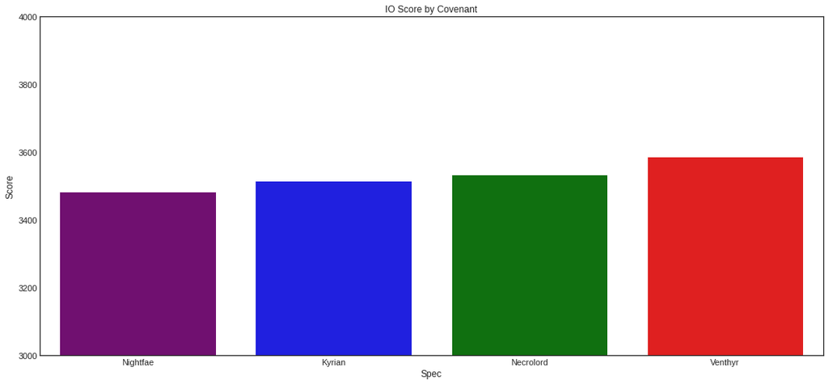

```python
sns.barplot(x='Covenant', y='Score', data=Dungeon92Ranks, palette=palletteUse, ci=None)
plt.style.use('seaborn-white')
plt.title('IO Score by Covenant')
plt.xlabel('Spec')
plt.ylabel('Score')
plt.ylim(3000, 4000)
plt.show()
```

To address this, we can identify the number of top 10 players for each class and covenant, and each spec and covenant pairing.

```python
covenant92Data1 = Dungeon92Ranks.groupby(['Class', 'Covenant']).size().reset_index(name='Count')
covenant92Data2 = Dungeon92Ranks.groupby(['Spec', 'Covenant']).size().reset_index(name='Count')
```

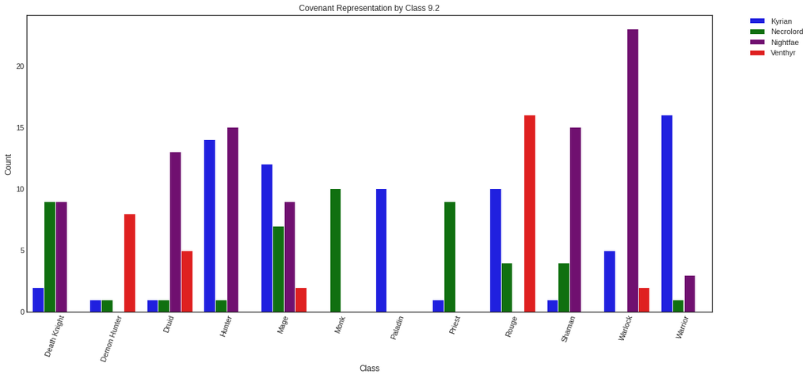

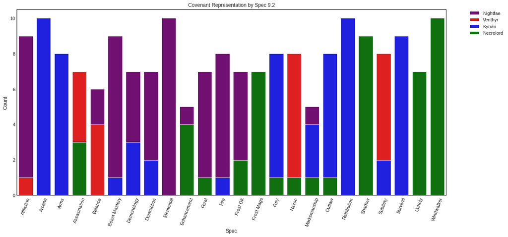

```python
sns.barplot(x='Class', y='Count', hue='Covenant', data=covenant92Data1, palette=palletteUse)
plt.style.use('seaborn-white')
plt.title('Covenant Representation by Class 9.2')
plt.xlabel('Class')
plt.ylabel('Count')
plt.xticks(rotation=70)
plt.legend(bbox_to_anchor=(1.05, 1), loc=2, borderaxespad=0.)
plt.show()

sns.barplot(x='Spec', y='Count', hue='Covenant', data=covenant92Data2, dodge=False, palette=palletteUse)
plt.style.use('seaborn-white')
plt.title('Covenant Representation by Spec 9.2')
plt.xlabel('Spec')
plt.ylabel('Count')
plt.xticks(rotation=70)
plt.legend(bbox_to_anchor=(1.05, 1), loc=2, borderaxespad=0.)
plt.show()
```

Clearly, only a few classes have any covenant diversity. Paladins and Monks only use one covenant, and for most specs, one covenant is a clear winner in popularity. In 9.0, the launch of Shadowlands, swapping covenants not only reset all progress in terms of power progression, but swapping back to a covenant one has left was time gated behind a two week waiting period. I would like to highlight the failure of the system in regards to allowing players to choose freely, indicating an imaginary balance between covenants for each class, but the mandated friction only compounds the issue of covenant imbalance.

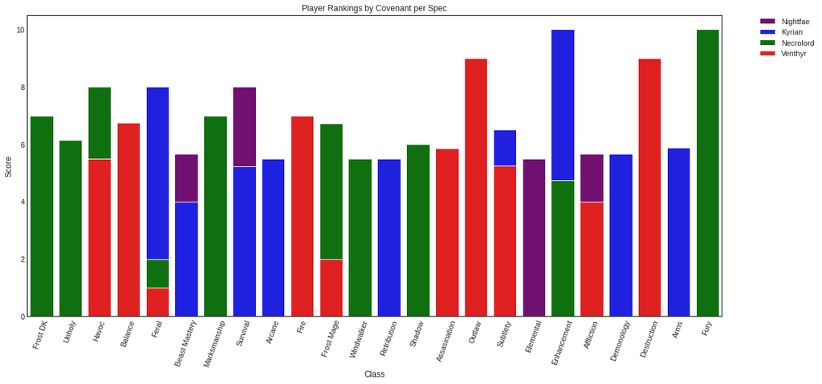

```python
sns.barplot(x='Spec', y='Rank', hue='Covenant', data=Dungeon92Ranks, dodge=False, palette=palletteUse, ci=None)
plt.style.use('seaborn-white')
plt.title('Player Rankings by Covenant per Spec')
plt.xlabel('Class')
plt.ylabel('Score')
plt.xticks(rotation=70)
plt.legend(bbox_to_anchor=(1.05, 1), loc=2, borderaxespad=0.)
plt.show()
```

We can see from the plot above that some covenants:

1. Are not seen at all.
2. Suboptimal covenants tend to fall lower in the spec rankings (minus a few outliers, such as Arcane mage where the playstyle is very different without kyrian), but this may not be entirely accurate, as high end players are more likely to select the best option already, and some covenant abilities can find niche uses.

Earlier I stated that the launch patch of Shadowlands had much more friction in swapping covenants than the current retail patch of 9.2. Let's repeat this analysis with the older 9.0 data.

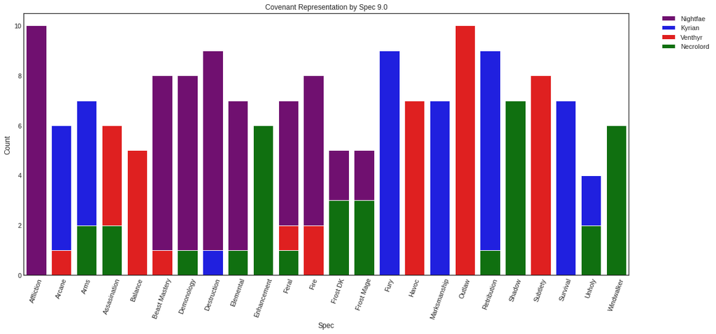

```python
Dungeon90Ranks = pd.read_csv('WowDungeon9.0Rankings.csv')
covenant90Data1 = Dungeon90Ranks.groupby(['Spec', 'Covenant']).size().reset_index(name='Count')
sns.barplot(x='Spec', y='Count', hue='Covenant', data=covenant90Data1, dodge=False,palette=palletteUse, ci=None)
plt.style.use('seaborn-white')
plt.title('Covenant Representation by Spec 9.0')
plt.xlabel('Spec')
plt.ylabel('Count')
plt.xticks(rotation=70)
plt.legend(bbox_to_anchor=(1.05, 1), loc=2, borderaxespad=0.)
plt.show()
```

The covenant distribution here has some interesting features in 9.0. Affliction and Outlaw have lost all diversity entirely, indicating a possible "best" choice, but specs such as Arcane mage and Arms warrior have a bit more diversity. Perhaps this was due to a difference in covenant balancing, allowing for more personal freedom, or perhaps the friction made swapping to a different covenant harder, so players chose not to.

Speaking of imbalance, let's focus back on dungeon performance across Shadowland's history. When choosing a class to play, most players end up playing one or two classes at most. This changes by season and expansion, but the ease of creating a new character varies, so the initial choice of what to play at the start does matter, so how did classes perform over the course of the expansion? Were players able to at some point feel value in their decision?

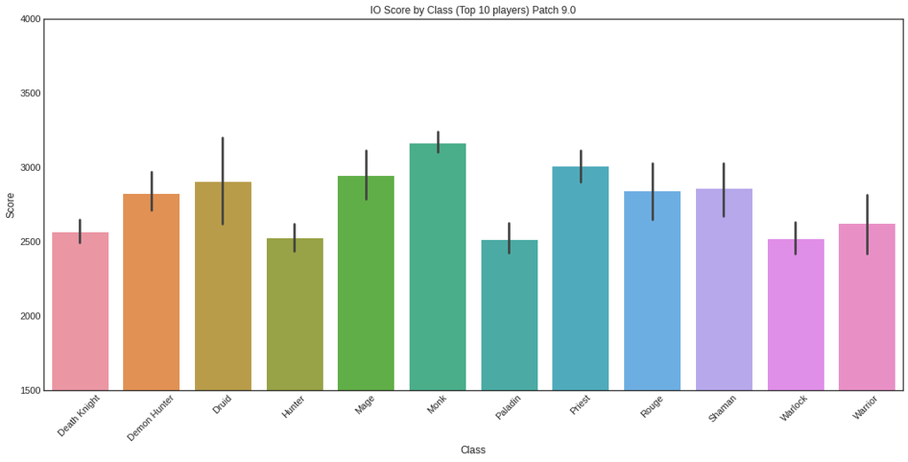

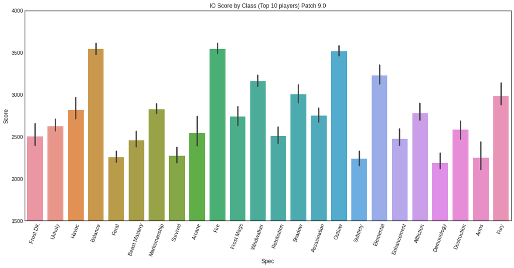

```python
sns.barplot(x='Class', y='Score', data=Dungeon90Ranks)
plt.xticks(rotation=45)
plt.style.use('seaborn-white')
plt.title('IO Score by Class (Top 10 players) Patch 9.0')
plt.xlabel('Class')
plt.ylabel('Score')
plt.ylim(1500, 4000)
plt.show()

sns.barplot(x='Spec', y='Score', data=Dungeon90Ranks)
plt.xticks(rotation=70)
plt.style.use('seaborn-white')
plt.title('IO Score by Class (Top 10 players) Patch 9.0')
plt.xlabel('Spec')
plt.ylabel('Score')
plt.ylim(1500, 4000)
plt.show()
```

The first factor of note is that the scale of IO score is less in 9.0 than in 9.2. This would be due to player power creep over the course of the expansion, with player strength scaling exponentially, meaning higher keys are able to be completed in the later season compared to the launch season. However, when looking at class and spec performance by relation, we can see a number of different trends in the difference of season. Certain specs, such as Fire mage and Sub rouge, have very different performances compared to their peers in the different patches. Fire was very successful in 9.0, and Sub was as well in 9.2, but in the opposite patches the specs fell off. Let's compare all the spec performances, accounting for the difference in mean score through standardizing across a patch.

```python
mean90 = Dungeon90Ranks.Score.mean()
std90 = Dungeon90Ranks.Score.std()

temp90 = Dungeon90Ranks.groupby(['Spec']).mean()
temp90.reset_index(inplace=True)
temp90.drop(columns=['Rank'])

for index, row in temp90.iterrows():
    temp90.at[index, 'Score'] = (temp90.at[index, 'Score'] - mean90) / std90
```

```python
mean92 = Dungeon92Ranks.Score.mean()
std92 = Dungeon92Ranks.Score.std()

temp92 = Dungeon92Ranks.groupby(['Spec']).mean()
temp92.reset_index(inplace=True)
temp92.drop(columns=['Rank'])

for index, row in temp92.iterrows():
    temp92.at[index, 'Score'] = (temp92.at[index, 'Score'] - mean92) / std92
```

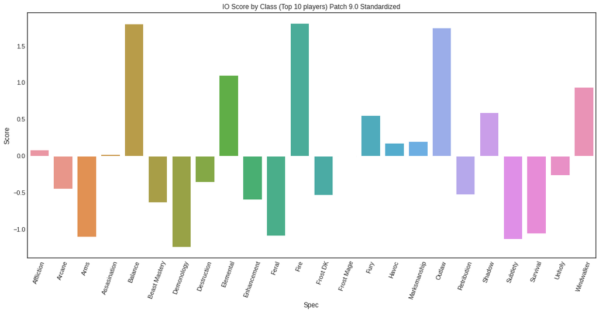

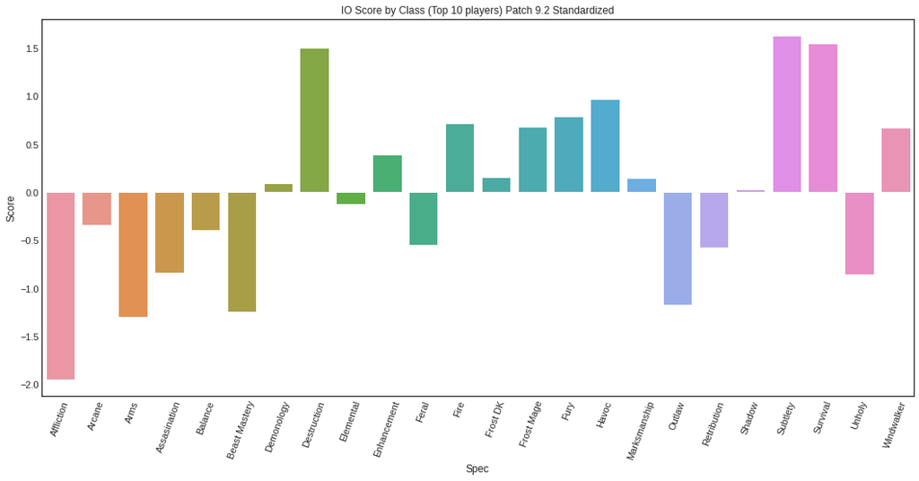

```python
sns.barplot(x='Spec', y='Score', data=temp90)
plt.xticks(rotation=70)
plt.style.use('seaborn-white')
plt.title('IO Score by Class (Top 10 players) Patch 9.0 Standardized')
plt.xlabel('Spec')
plt.ylabel('Score')
plt.show()

sns.barplot(x='Spec', y='Score', data=temp92)
plt.xticks(rotation=70)
plt.style.use('seaborn-white')
plt.title('IO Score by Class (Top 10 players) Patch 9.2 Standardized')
plt.xlabel('Spec')
plt.ylabel('Score')
plt.show()
```

From here we can clearly see a spec's performance in relation to the expected imaginary average spec, but next we need to plot across the course of the expansion to answer our question.

```python
residualSpec = temp92.copy()
for index, row in temp92.iterrows():
    residualSpec.at[index, 'Score'] = (temp92.at[index, 'Score'] - temp90.at[index, 'Score'])
```

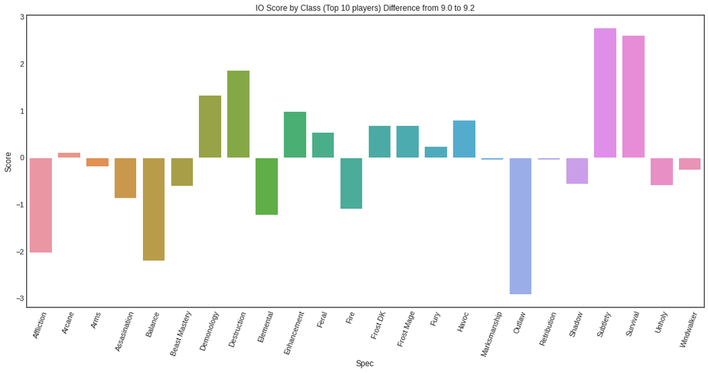

```python
sns.barplot(x='Spec', y='Score', data=residualSpec)
plt.xticks(rotation=70)
plt.style.use('seaborn-white')
plt.title('IO Score by Class (Top 10 players) Difference from 9.0 to 9.2')
plt.xlabel('Spec')
plt.ylabel('Score')
plt.show()
```

This new plot is able to show relative spec IO performance over the entire expansion, from 9.0 to 9.2. People who chose outlaw clearly got the short end of the stick, where once a top performing spec is now bottom tier in 9.2. This data does require looking at initial spec performance, because one would believe affliction to be in a similar state as outlaw, but in truth, affliction was never top tier to begin with, yet was never buffed in compensation. Balance also seems to have fall off hard, just as outlaw, but again this is misleading. In reality, balance was so extremely ahead in 9.0, that in 9.2, it is actually quite average, yet the standardization would have one think it was terrible. I imagine players who chose warlock and wanted to play Affliction, like myself, feel neglected by the game's balance team.

With all the knowledge we now have, the big question left is "Should I play melee or ranged dps in the new WoW expansion: Dragonflight?"

While of course everything here will be speculation, we can use past trends to find the specs that have a history of success over the course of expansions. Dungeons so far have always had "trash," which are enemies to kill in area of effect damage, and dungeons always have bosses with their own mechanics. Based on past performance over many dungeons and seasons, we can hope to predict some top classes that always find their way into the meta. The choice of melee or ranged can be used as a guide for developing a dungeon team composition, so this initial choice will end up being important for competitive groups.

```python
# This function will determine which data set to use, between 9.0 and 9.2 data combined as residuals, or 9.0 and 9.2 residuals locally combined.
def optionFunction(oneOrTwo):
    # OPTION 1
    # Delineate melee and ranged across 9.0 and 9.2 patches together
    if oneOrTwo == 1:
        mlFrame = temp90.copy()
        print('Melee and Ranged standardized from 9.0:')
    elif oneOrTwo == 2:
        mlFrame = temp92.copy()
        print('Melee and Ranged standardized from 9.2:')
    else:
        # OPTION 2
        # Residuals of 9.2 - 9.0
        mlFrame = residualSpec.copy()
        print('Melee and Ranged patches standardized together:')

    # Continue function
    mlFrame = mlFrame.reset_index()
    mlFrame = mlFrame.drop(columns=['Rank', 'index'])
    mlFrame['Melee'] = 0

    # Correctly match each category to each spec
    for index, row in mlFrame.iterrows():
        if mlFrame.at[index, 'Spec'] == 'Arms':
            mlFrame.at[index, 'Melee'] = 1
        elif mlFrame.at[index, 'Spec'] == 'Assasination':
              mlFrame.at[index, 'Melee'] = 1
        elif mlFrame.at[index, 'Spec'] == 'Enhancement':
              mlFrame.at[index, 'Melee'] = 1
        elif mlFrame.at[index, 'Spec'] == 'Feral':
              mlFrame.at[index, 'Melee'] = 1
        elif mlFrame.at[index, 'Spec'] == 'Frost DK':
              mlFrame.at[index, 'Melee'] = 1
        elif mlFrame.at[index, 'Spec'] == 'Fury':
              mlFrame.at[index, 'Melee'] = 1
        elif mlFrame.at[index, 'Spec'] == 'Havoc':
              mlFrame.at[index, 'Melee'] = 1
        elif mlFrame.at[index, 'Spec'] == 'Outlaw':
              mlFrame.at[index, 'Melee'] = 1
        elif mlFrame.at[index, 'Spec'] == 'Retribution':
              mlFrame.at[index, 'Melee'] = 1
        elif mlFrame.at[index, 'Spec'] == 'Subtlety':
              mlFrame.at[index, 'Melee'] = 1
        elif mlFrame.at[index, 'Spec'] == 'Survival':
              mlFrame.at[index, 'Melee'] = 1
        elif mlFrame.at[index, 'Spec'] == 'Unholy':
              mlFrame.at[index, 'Melee'] = 1
        elif mlFrame.at[index, 'Spec'] == 'Windwalker':
              mlFrame.at[index, 'Melee'] = 1


    mlFrameMelee = mlFrame.groupby('Melee').mean()

    # Threshold to be considered ranged dps
    global rangedMark
    rangedMark = mlFrameMelee.at[0, 'Score']

    # Threshold to be considered melee dps
    global meleeMark
    meleeMark = mlFrameMelee.at[1, 'Score']
    print('Melee average over data:', meleeMark)
    print('Ranged average over data:', rangedMark)
    return mlFrame
```

To determine whether a spec is melee or range, we will train a model on the set over the residual IO scores across 9.0 and 9.2. The hope is that the model will be able to accurately predict melee or range for a spec based on IO performance, which will then tell us how much we can know about the classes through IO.

```python
# Our Model
def meleeOrRangedModel(specName, marker, df, index):
    IoScore = df.at[index, 'Score']
    # Compare the spec's IO to the threshold of the melee or range marker to decide if the spec is melee or range
    score = 0
    if IoScore >= marker:
        return True
    else:
        return False
```

```python
# Model can use either the melee or ranged threshold markers
def trainModel(df, melee):
    accuracyCounter = 0
    if melee == 0:
        for index, row in df.iterrows():
            # If correct prediction, increase accuracy tally
            specName = df.at[index, 'Spec']
            if meleeOrRangedModel(specName, rangedMark, df, index) == df.at[index, 'Melee']:
                accuracyCounter = accuracyCounter + 1
    else:
        for index, row in df.iterrows():
            # If correct prediction, increase accuracy tally
            specName = df.at[index, 'Spec']
            if meleeOrRangedModel(specName, meleeMark, df, index) == df.at[index, 'Melee']:
                accuracyCounter = accuracyCounter + 1
    return (accuracyCounter / len(df.index)) * 100
```

```python
# Check accuracy on predicting the number of melee specs and ranged specs
mlFrame = optionFunction(1)
print("Accuracy of classifying melee specs:", trainModel(mlFrame, 0))
print("Accuracy of classifying ranged specs:", trainModel(mlFrame, 1), '\n')

mlFrame = optionFunction(2)
print("Accuracy of classifying melee specs:", trainModel(mlFrame, 0))
print("Accuracy of classifying ranged specs:", trainModel(mlFrame, 1), '\n')

mlFrame = optionFunction(3)
print("Accuracy of classifying melee specs:", trainModel(mlFrame, 0))
print("Accuracy of classifying ranged specs:", trainModel(mlFrame, 1))
```

```
Melee and Ranged standardized from 9.0:
Melee average over data: -0.22103436844798793
Ranged average over data: 0.26122243543852386
Accuracy of classifying melee specs: 41.66666666666667
Accuracy of classifying ranged specs: 37.5

Melee and Ranged standardized from 9.2:
Melee average over data: 0.06784277659526201
Ranged average over data: -0.08017782688530987
Accuracy of classifying melee specs: 50.0
Accuracy of classifying ranged specs: 54.166666666666664

Melee and Ranged patches standardized together:
Melee average over data: 0.2888771450432499
Ranged average over data: -0.3414002623238337
Accuracy of classifying melee specs: 66.66666666666666
Accuracy of classifying ranged specs: 58.333333333333336
```

We can understand a lot about the classes from the results of the three model trainings. The first set is trained soley on data from the start of Shadowlands. We can see that the melee performed below average compared to their ranged counterpart, while the opposite is true when the data is trained on the later patch of 9.2. This would indicate a shift in balance towards the end of the expansion, or at the very least, a shift in class popularity in the high end playerbase.

The model was terrible at identifying both melee and ranged classes correctly at the start of the Shadowlands expansion. Low detection would seem to suggest an imbalance amongst the melee and ranged classes within themselves, which holds up with our own analysis. Affliction Warlocks suffering all expansion, while Balance Druids take over for the 9.0 launch patch for the ranged categories, along with certain melee classes excelling far beyond others for the melee (Windwalker Monks compared to Survival Hunters).

By the 9.2 patch, the model significantly improved at both melee and ranged detection (noting that melee is still 50/50 guess, but still an improvement), while ranged is at least a positive detection. This would suggest that overall melee specs became closer to each other, and the same for ranged. If one were to create a new character in 9.2, there is less of a punishing experience in choosing the "wrong" spec, at least within one's own melee or ranged bubble.

When looking at the scope of the entire expansion, melee spec's have a classification accuracy of 66.6%, while ranged are sub 60%. This seems to imply that across all melee specs, one can expect a consistent experience no matter the spec they choose. Ranged, with the 58.3%, is slightly more volatile.

Another feature of note is the Melee and Ranged average threshold for each data set. At launch, the melee dps had a below average IO score, sitting at about -0.22 compared to the other specs, while ranged dps were above average with 0.26 standardized IO. This reversed by the 9.2 patch, with melee slightly in the lead with 0.068, and ranged dps at -0.08. The gap had closed, and melee had slightly taken over. Overall, the game in 9.2 is in a much more balanced state. Melee are not ahead on average by much, compared to the drastic lead ranged had over melee in 9.0. We can even see over all the data from 9.0 and 9.2 together than melee took the lead over the course of the entire expansion.

Currently, in Dragonflight, the estimated model proved futile, with balance in dungeons each season being somewhat varied, but with shadow priests retaining a solid position in comps throughout season one and two. In retrospect, the model was lacking in both features and training data, as only ten entries for each spec is both limited in quantity and disingenuous to success on average. For example, fire mage historically excels in coordinated groups that pull around combustion, but outlaw rouge has a better cooldown profile on average. As for quantity, my model is also limited only to the highest end performance. By definition, the average player will not be able to perform at the highest level, so classes such as demon hunter, which perform better than other classes in heroic raid while falling behind in mythic raid, are less appreciated by my model.

In summation, I feel my analysis and conclusions of the limited data I collected seem fair, but my model training would benefit from more data and features to build and train on. In fact, a better question could be posed to have a model answer: instead of melee or ranged, perhaps question class or spec stability over an expansion?